```python
import pandas as pd
import matplotlib.pyplot as plt
import numpy as np
import math as math

%matplotlib inline
```

```python
# Loading data into data frame
train_set = pd.read_csv('train_set_values.csv')
train_label = pd.read_csv('train_set_labels.csv')
train_df = train_set.merge(train_label, on = 'id')

col_names = list(train_df.columns)

pd.set_option('display.max_columns', 41)
```

# 1. Understanding the dataset

The first step to any data science project is understanding the data and what insights we can possibly derive from it. There are 41 columns in this dataset where 39 columns are features or predictors to the functionality of the water pump. The columns provide hints for us to start making some early hypotheses on what affect a water pump's functionality.

To begin, we can start making a few hypotheses based on logical reasoning.

- The column amount_tsh seems misleading. By definition, it is the water produced by water pump measured from suction level. Logically, a pump would still be functional if it has no water. Furthermove, it is not mentioned whether this column is the average value of single value at time of entry. This column could be noise.
- Altitude is known to affect pump efficiency. Altitude can be derived from gps_height column. Therefore this might be a strong feature.
- Other factors that would be attributed for a water point failures could be regions, age of pump, management, payment, water quality, water source.

We will begin with some visualizations and statistical analysis.

```python
df_desc = train_df.describe(include='all')
ms_cnt = pd.DataFrame(59400 - df_desc.iloc[0])
ms_cnt['perc'] = (ms_cnt['count']/59400) * 100

# Percentage of missing values by columns
print(ms_cnt)
```

```
                       count      perc
id                         0         0
amount_tsh                 0         0
date_recorded              0         0
funder                  3635   6.11953
gps_height                 0         0
installer               3655    6.1532
longitude                  0         0
latitude                   0         0
wpt_name                   0         0
num_private                0         0
basin                      0         0
subvillage               371  0.624579
region                     0         0
region_code                0         0
district_code              0         0
lga                        0         0
ward                       0         0
population                 0         0
public_meeting          3334   5.61279
recorded_by                0         0
scheme_management       3877   6.52694
scheme_name            28166   47.4175
permit                  3056   5.14478
construction_year          0         0
extraction_type            0         0
extraction_type_group      0         0
extraction_type_class      0         0
management                 0         0
management_group           0         0
payment                    0         0
payment_type               0         0
water_quality              0         0
quality_group              0         0
quantity                   0         0
quantity_group             0         0
source                     0         0
source_type                0         0
source_class               0         0
waterpoint_type            0         0
waterpoint_type_group      0         0
status_group               0         0
```

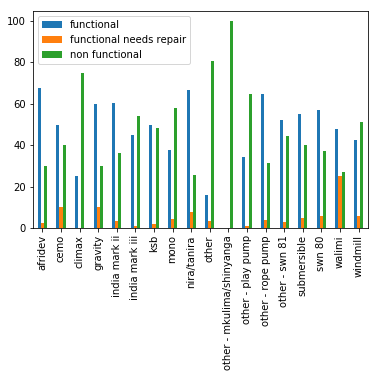

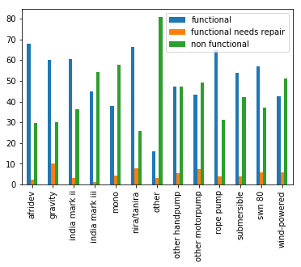

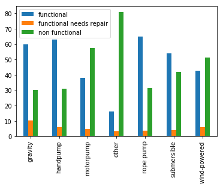

```python
# The column scheme_name is missing close to 50% of data. It seems logical to drop it and proceed to
# fill the other columns with low missing % using median, mean or distribution approach.

# train_df.drop(['scheme_name'], axis = 1, inplace = True)

fig = plt.figure(figsize=(8,4))
ctr = 1
def summarize_by_category(df, category):
    temp1 = df[category].value_counts()
    temp2 = df.groupby([category, 'status_group'])['status_group'].count()
    temp3 = pd.DataFrame()
    for i, val in temp2.iteritems():
        temp3.loc[i[0],i[1]] = 100.00*float(val)/float(temp1.loc[i[0]])
    return temp3

for ext in ['extraction_type', 'extraction_type_group', 'extraction_type_class']:
    sum_df = summarize_by_category(train_df, ext)
    sum_df.plot(kind='bar')

# It seems obvious that most of the values in column extraction_type can be summarized
# into extraction_type_class without much loss of information. Therefore, we may use this approach to reduce other
# columns which have similar context.
```

```python
a = train_df['funder'].value_counts().nlargest(10)
funder_stat_df = pd.DataFrame(columns = ['count', 'functional', 'functional needs repair', 'non functional'])
def funder_summary(df, count, category):
    temp1 = df[df['funder'] == category]
    temp2 = temp1.groupby(['funder', 'status_group'])['status_group'].count()
    for i, val in temp2.iteritems():
        funder_stat_df.loc[i[0], 'count'] = count
        funder_stat_df.loc[i[0],i[1]] = 100.00*float(val)/float(len(temp1))

for i, val in a.iteritems():
    funder_summary(train_df, val, i)
funder_stat_df

# It makes sense that the funder with more wells ownership will need more effort to maintain the wells. Also,
# the ownership may have started long time ago where some wells could have been abandoned. Hence the distribution of
# non functional wells funded under these group of funders are high. The funder column could actually be a bad feature
# if used as a sole predictor as it might infer that any well (including new ones) owned by
# these group of funders have high chance of being non-functional. This is something we have to becareful of and
# may need further deep dive such as how long have these funders been in the well funding activities.
```

|  | count | functional | functional needs repair | non functional |
| --- | --- | --- | --- | --- |
| Government Of Tanzania | 9084 | 40.9511 | 7.71686 | 51.332 |
| Danida | 3114 | 55.0096 | 5.10597 | 39.8844 |
| Hesawa | 2202 | 42.5068 | 10.5359 | 46.9573 |
| Rwssp | 1374 | 58.5881 | 7.93304 | 33.4789 |
| World Bank | 1349 | 40.4003 | 7.19051 | 52.4092 |
| Kkkt | 1287 | 56.1772 | 5.12821 | 38.6946 |
| World Vision | 1246 | 59.6308 | 10.5136 | 29.8555 |
| Unicef | 1057 | 56.7644 | 9.36613 | 33.8694 |
| Tasaf | 877 | 56.2144 | 7.29761 | 36.488 |
| District Council | 843 | 44.8399 | 5.33808 | 49.8221 |

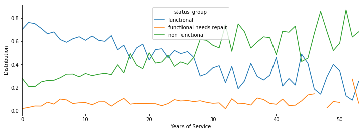

```python
# Let's first study if waterpoint functionality is affected by years of service.
# There is high chance that this will be true.
year_df = train_df[train_df['construction_year'] != 0].copy()
year_df['years_of_service'] = year_df['date_recorded'].apply(lambda x: x[:4]).astype(int) - year_df['construction_year'].astype(int)

# For contextual purposes, construction_year 0 is removed from analysis.
temp = year_df[year_df['construction_year'] != 0]
# Construction year should be prior to date_recorded, hence a negative value in years_of_service probably indicates
# bad value and hence is removed from analysis
temp['construction_year'].value_counts()
temp = temp[temp['years_of_service'] >= 0]
gb = temp.groupby(['years_of_service', 'status_group']).count()
temp2 = pd.DataFrame(temp.groupby(['years_of_service', 'status_group'])['status_group'].count())
temp3 = temp2.groupby(['years_of_service']).sum()
temp2['perc'] = temp2['status_group']/temp3['status_group']
test = temp2.unstack()
ax = test['perc'].plot(kind='line', figsize=(12,4))
ax.set_ylabel('Distribution')
ax.set_xlabel('Years of Service')

# The trends somewhat coincide with our hypothesis that waterpoint functionality is related to its age or years of
# service. In this case, the distribution of non functional wells increases with increasing years of service.
# This should be a good feature. Since the class 'functional needs repair' is imbalance in this data, its normal
# to not see an obvious trend there. Furthermore, we could foresee that the prediction performance in this class
# will be less impressive.
```

```python
# Installer could be a potential indicator on a water point functionality. Proper installation definitely will pro-long
# the lifespan of the water pump. We will see below that certain installer does have pretty bad record.

code = 'installer'
train_df[code].value_counts()

a = train_df[code].value_counts().nlargest(10)
stat_df = pd.DataFrame(columns = ['count', 'functional', 'functional needs repair', 'non functional'])
def stat_summary(df, count, category):
    temp1 = df[df[code] == category]
    temp2 = temp1.groupby([code, 'status_group'])['status_group'].count()
    for i, val in temp2.iteritems():
        stat_df.loc[i[0], 'count'] = count
        stat_df.loc[i[0],i[1]] = 100.00*float(val)/float(len(temp1))

for i, val in a.iteritems():
    stat_summary(train_df, val, i)
stat_df
```

|  | count | functional | functional needs repair | non functional |
| --- | --- | --- | --- | --- |
| DWE | 17402 | 54.2064 | 9.32077 | 36.4728 |
| Government | 1825 | 29.3151 | 14.0274 | 56.6575 |
| RWE | 1206 | 25.2073 | 11.3599 | 63.4328 |
| Commu | 1060 | 68.3019 | 3.01887 | 28.6792 |
| DANIDA | 1050 | 51.619 | 7.90476 | 40.4762 |
| KKKT | 898 | 46.9933 | 6.90423 | 46.1024 |
| Hesawa | 840 | 56.5476 | 2.02381 | 41.4286 |
| 0 | 777 | 57.2716 | 0.3861 | 42.3423 |
| TCRS | 707 | 41.0184 | 5.94059 | 53.041 |
| Central government | 622 | 27.0096 | 0.643087 | 72.3473 |